# Question 3

Karen Abraham

12-09-2021

# Question 3: Which actors have been involved in the most conflicts since 1989?

## Loading Data and Libraries

```r
#clear environment
rm(list = ls())
options(warn=-1)

#loading libraries (must be installed before where necessary)
library(readr)
library(dplyr)
```

```r
library(ggplot2)
library(network)
library(igraph)
library(centiserve)
library(tidygraph)
library(networkD3)
library(visNetwork)
library(htmlwidgets)
library(ggraph)
```

```r
#Loading the dataset
ged211 <- read_csv("ged211.csv")
head(ged211)
```

| id | relid | year | active_year | code_status | type_of_violence | conflict_dset_id | conflict_new_id | conflict_name | dyad_dset_id | dyad_new_id | dyad_name | side_a_dset_id | side_a_new_id | side_a | side_b_dset_id | side_b_new_id | side_b | number_of_sources | source_article | source_office | source_date | source_headline | source_original | where_prec | where_coordinates | where_description | adm_1 | adm_2 | latitude | … |
| --- | --- | --- | --- | --- | --- | --- | --- | --- | --- | --- | --- | --- | --- | --- | --- | --- | --- | --- | --- | --- | --- | --- | --- | --- | --- | --- | --- | --- | --- | --- |
| 244657 | IRQ-2017-1-524-322 | 2017 | 1 | Clear | 1 | 259 | 259 | Iraq: Government | 524 | 524 | Government of Iraq - IS | 116 | 116 | Government of Iraq | 234 | 234 | IS | 3 | "Agence France Presse,2017-08-01,Attackers target Shiite mosque in Afghanistan's Herat";"Agence France Presse,2017-08-01,At least 20 killed in Shiite mosque attack in Afghanistan's Herat";"Pajhwok New… | Agence France Presse;Agence France Presse;Pajhwok News | 2017-08-01;2017-08-01;2017-07-31 | Attackers target Shiite mosque in Afghanistan's Herat;At least 20 killed in Shiite mosque attack in Afghanistan's Herat;Assailants among 6 killed in Iraq Embassy attack | IS, interior ministry, security source | 1 | Kabul city | Iraqi embassy in Kabul | Kabul province | Kabul district | 34.53109 | … |
| 132140 | AFG-1989-1-411-2 | 1989 | 1 | Clear | 1 | 333 | 333 | Afghanistan: Government | 724 | 724 | Government of Afghanistan - Jam'iyyat-i Islami-yi Afghanistan | 130 | 130 | Government of Afghanistan | 292 | 292 | Jam'iyyat-i Islami-yi Afghanistan | -1 | The Times 13 Jan 1989 "Missiles and tea breaks for rebels;Afghanistan | NA | NA | NA | Rebel source | 4 | Nangarhar province | Nangarhar province | Nangarhar province | NA | 34.33333 | … |
| 130364 | AFG-1989-1-411-37 | 1989 | 1 | Clear | 1 | 333 | 333 | Afghanistan: Government | 724 | 724 | Government of Afghanistan - Jam'iyyat-i Islami-yi Afghanistan | 130 | 130 | Government of Afghanistan | 292 | 292 | Jam'iyyat-i Islami-yi Afghanistan | -1 | R 18 Jan 1989 "KABUL REPORTS HUNDREDS OF REBEL CASUALTIES IN KUNDUZ PROVINCE. | NA | NA | NA | Kabul radio (monitored in Islamabad) | 4 | Kunduz province | Kunduz province | Kunduz province | NA | 36.75000 | … |
| 130359 | AFG-1989-1-411-4 | 1989 | 1 | Clear | 1 | 333 | 333 | Afghanistan: Government | 724 | 724 | Government of Afghanistan - Jam'iyyat-i Islami-yi Afghanistan | 130 | 130 | Government of Afghanistan | 292 | 292 | Jam'iyyat-i Islami-yi Afghanistan | -1 | Reuters 24 Jan 1989 "AFGHANS KILL NEARLY 400 REBELS, TASS SAYS." /The Washington Post 27 Jan 1989 "Rebels Send Food Convoy To Kabul;U.S. Orders Embassy Evacuated, Closed" /The Toronto Star 28 Jan 1989… | NA | NA | NA | Tass news agency /Western diplomats quoting witnesses /Rebel spokesman | 1 | Salang pass | Salang pass (on the main highway linking Kabul with the Soviet border) | Baghlan province | Khinjan district | 35.31583 | … |
| 133883 | AFG-1989-1-411-39 | 1989 | 1 | Clear | 1 | 333 | 333 | Afghanistan: Government | 724 | 724 | Government of Afghanistan - Jam'iyyat-i Islami-yi Afghanistan | 130 | 130 | Government of Afghanistan | 292 | 292 | Jam'iyyat-i Islami-yi Afghanistan | -1 | The Sunday Times 5 Feb 1989 "The Russians move out...;Withdrawal from Afghanistan | NA | NA | NA | Military spokesman | 1 | Kabul city | Kabul city | Kabul province | Kabul district | 34.53109 | … |
| 133874 | AFG-1989-1-411-6 | 1989 | 1 | Clear | 1 | 333 | 333 | Afghanistan: Government | 724 | 724 | Government of Afghanistan - Jam'iyyat-i Islami-yi Afghanistan | 130 | 130 | Government of Afghanistan | 292 | 292 | Jam'iyyat-i Islami-yi Afghanistan | -1 | St. Louis Post-Dispatch 1 Feb 1989 "JET CARRYING U.S. ENVOYS NEARLY HITS SOVIET PLANE | NA | NA | NA | Rebel spokesman | 2 | Salang tunnel | Salang tunnel (near, villages near the main Soviet withdrawal route, Salang tunnel) | Baghlan province | Khinjan district | 35.31603 | … |

# Network Analysis

## Creating the network

First we need a usable dataframe

```r
#Lets take each instance with a death toll over 0 and create a df with only side_a, side_b and total death toll
#remove type of violence =3 because civilians are not considered actors
over0 <- subset(ged211, best>0 & type_of_violence!=3)
over0 <- cbind.data.frame(over0$side_a,over0$side_b,over0$best)
colnames(over0) <- c("side_a","side_b","best")

#Grouping and totalling
gpd <- aggregate(over0$best, list(over0$side_a,over0$side_b), FUN=sum)
colnames(gpd) <- c("side_a","side_b","total")
gpd <- gpd %>% arrange(desc(gpd$total))

#Look at the top values
head(gpd)
```

|  | side_a | side_b | total |
| --- | --- | --- | --- |
| 1 | Government of Syria | Syrian insurgents | 277696 |
| 2 | Government of Afghanistan | Taleban | 195280 |
| 3 | Government of Eritrea | Government of Ethiopia | 98217 |
| 4 | Government of Iraq | IS | 62449 |
| 5 | Government of Sri Lanka | LTTE | 60697 |
| 6 | Government of Syria | IS | 45666 |

Then we need to get all the nodes, which are actors listed in either side_a or side_b

```r
#All actors listed in side_a
sides_a <- gpd %>%
  distinct(side_a)

#All actors listed in side_b
sides_b <- gpd %>%
  distinct(side_b)

colnames(sides_a) <- c("sides")
colnames(sides_b) <- c("sides")

#Defining the nodes
nodes <- full_join(sides_a, sides_b, by = "sides")

#Defining the edges
edges <- gpd %>%
  left_join(nodes, by = c("side_a" = "sides"))

edges <- edges %>%
  left_join(nodes, by = c("side_b" = "sides"))
```

Now we can create the network

```r
#Bidirectional so multiple set to true
routes_network <- network(edges, vertex.attr = nodes, matrix.type = "edgelist",ignore.eval = FALSE, multiple=TRUE)

#Checking we have created a network
class(routes_network)
```

```
## [1] "network"
```

```r
routes_network
```

```
##  Network attributes:
##   vertices = 1325
##   directed = TRUE
##   hyper = FALSE
##   loops = FALSE
##   multiple = TRUE
##   bipartite = FALSE
##   total edges= 1212
##     missing edges= 0
##     non-missing edges= 1212
##
##  Vertex attribute names:
##     sides vertex.names
##
##  Edge attribute names not shown
```

Now the network can be plotted

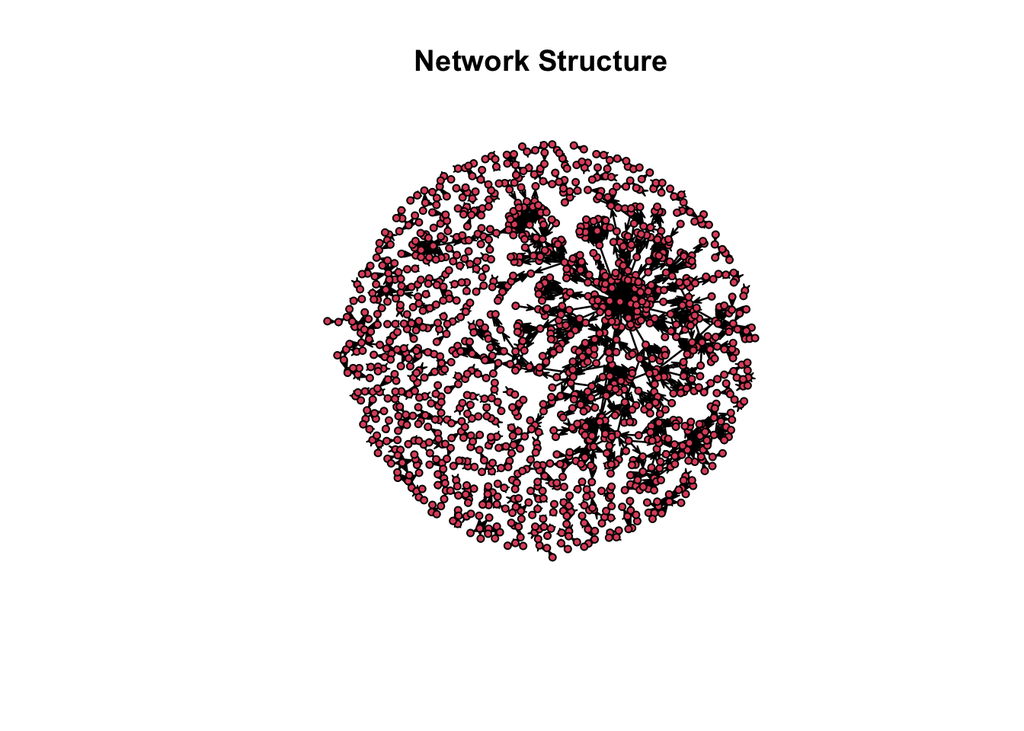

```r
plot(routes_network, vertex.cex = 0.8, main="Network Structure")
```

Although this gives us a little bit of insight into the structure, it is not very meaningful by itself, so let’s work with an igraph

```r
routes_igraph <- graph_from_data_frame(d = edges, vertices = nodes, directed = TRUE)
routes_igraph
```

```
## IGRAPH 610f0eb DN-- 1325 1212 --
## + attr: name (v/c), total (e/n)
## + edges from 610f0eb (vertex names):
##  [1] Government of Syria      ->Syrian insurgents
##  [2] Government of Afghanistan->Taleban
##  [3] Government of Eritrea    ->Government of Ethiopia
##  [4] Government of Iraq       ->IS
##  [5] Government of Sri Lanka  ->LTTE
##  [6] Government of Syria      ->IS
##  [7] Government of Ethiopia   ->EPLF
##  [8] Government of Ethiopia   ->EPRDF
## + ... omitted several edges
```

Using this network, we can easily query information on whether two actors are in conflict

```r
are.connected(routes_igraph,"Government of India","Government of Pakistan") #TRUE
```

```
## [1] TRUE
```

```r
are.connected(routes_igraph,"Government of Syria","IS") #TRUE
```

```
## [1] TRUE
```

```r
are.connected(routes_igraph,"Government of Syria","Government of Pakistan") #FALSE
```

```
## [1] FALSE
```

We can also display the network as an edge list for each actor

```r
(as_adj_edge_list(routes_igraph))$`Government of Syria`
```

```
## + 4/1212 edges from 610f0eb (vertex names):
## [1] Government of Syria->IS
## [2] Government of Syria->Syrian insurgents
## [3] Government of Syria->SDF
## [4] Government of Syria->PYD
```

```r
routes_network
```

```
##  Network attributes:
##   vertices = 1325
##   directed = TRUE
##   hyper = FALSE
##   loops = FALSE
##   multiple = TRUE
##   bipartite = FALSE
##   total edges= 1212
##     missing edges= 0
##     non-missing edges= 1212
##
##  Vertex attribute names:
##     sides vertex.names
##
##  Edge attribute names not shown
```

```r
V(routes_igraph)$all <- degree(routes_igraph, mode = "all")

#Which actors have more than 10 times the median number of edges (most interconnected vertices)?
V(routes_igraph)[V(routes_igraph)$all > 10*median(V(routes_igraph)$all)]
```

```
## + 15/1325 vertices, named, from 610f0eb:
##  [1] Government of Afghanistan      Government of Ethiopia
##  [3] Government of Sudan            Government of Pakistan
##  [5] IS                             Government of India
##  [7] Government of Philippines      Government of DR Congo (Zaire)
##  [9] Government of Myanmar (Burma)  Government of Chad
## [11] Fulani                         Government of Mali
## [13] Borana                         SDF
## [15] PYD
```

## Degree Distribution

What does the distribution of edges look like

```r
#Minimum number of edges in network
min(degree(routes_igraph))
```

```
## [1] 1
```

```r
#Maximum number of edges in network
max(degree(routes_igraph))
```

```
## [1] 101
```

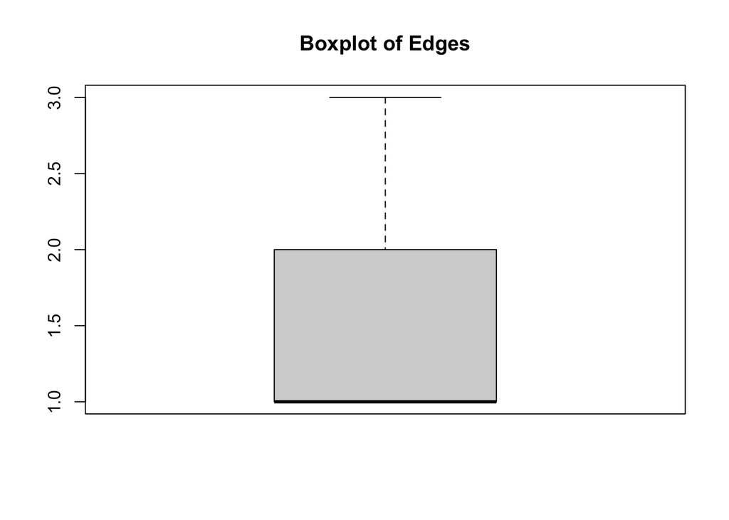

```r
#Boxplot with distr of edges
boxplot(V(routes_igraph)$all, outline=FALSE, main="Boxplot of Edges")
```

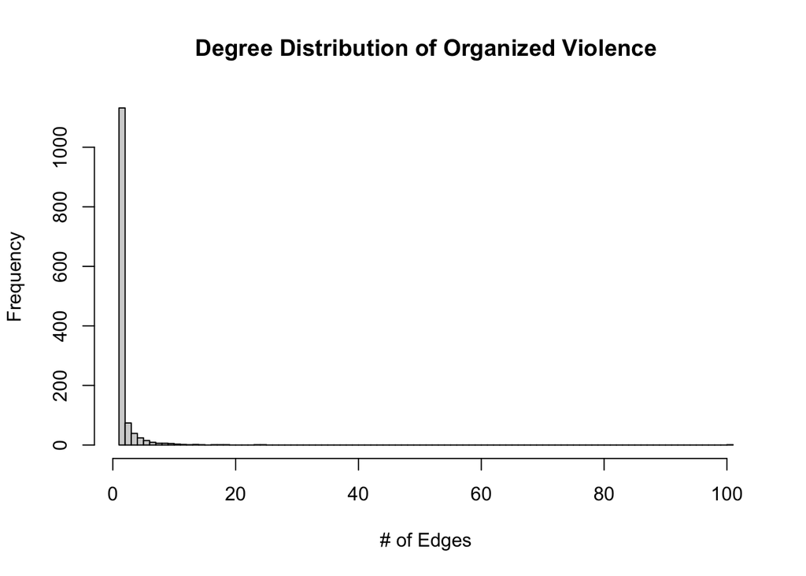

```r
#Vertex degree distr
hist(V(routes_igraph)$all, breaks=100, main="Degree Distribution of Organized Violence",xlab="# of Edges")
```

```r
degree_distribution(routes_igraph)
```

```
##   [1] 0.000000000 0.724528302 0.129811321 0.055849057 0.029433962 0.018113208
##   [7] 0.011320755 0.006792453 0.004528302 0.004528302 0.003773585 0.002264151
##  [13] 0.001509434 0.000754717 0.001509434 0.000754717 0.000000000 0.000754717
##  [19] 0.000754717 0.000754717 0.000000000 0.000000000 0.000000000 0.000000000
##  [25] 0.000754717 0.000754717 0.000000000 0.000000000 0.000000000 0.000000000
##  [31] 0.000000000 0.000000000 0.000000000 0.000000000 0.000000000 0.000000000
##  [37] 0.000000000 0.000000000 0.000000000 0.000000000 0.000000000 0.000000000
##  [43] 0.000000000 0.000000000 0.000000000 0.000000000 0.000000000 0.000000000
##  [49] 0.000000000 0.000000000 0.000000000 0.000000000 0.000000000 0.000000000
##  [55] 0.000000000 0.000000000 0.000000000 0.000000000 0.000000000 0.000000000
##  [61] 0.000000000 0.000000000 0.000000000 0.000000000 0.000000000 0.000000000
##  [67] 0.000000000 0.000000000 0.000000000 0.000000000 0.000000000 0.000000000
##  [73] 0.000000000 0.000000000 0.000000000 0.000000000 0.000000000 0.000000000
##  [79] 0.000000000 0.000000000 0.000000000 0.000000000 0.000000000 0.000000000
##  [85] 0.000000000 0.000000000 0.000000000 0.000000000 0.000000000 0.000000000
##  [91] 0.000000000 0.000000000 0.000000000 0.000000000 0.000000000 0.000000000
##  [97] 0.000000000 0.000000000 0.000000000 0.000000000 0.000000000 0.000754717
```

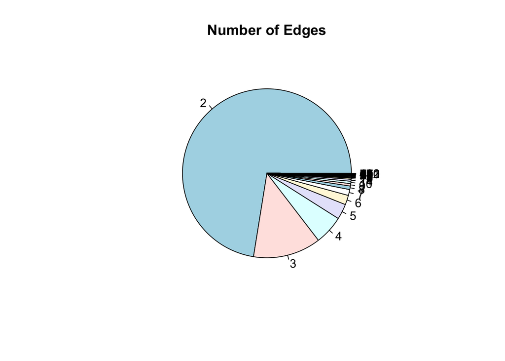

```r
#For degree_distribution a numeric vector of the same length as the maximum degree plus one. The first element is the relative frequency zero degree vertices, the second vertices with degree one, etc.

pie(degree_distribution(routes_igraph),main="Number of Edges")
```

```r
#Number of vertices
gorder(routes_igraph)
```

```
## [1] 1325
```

```r
#Number of edges
gsize(routes_igraph)
```

```
## [1] 1212
```

```r
#Reading degrees of actors
head(degree(routes_igraph))
```

```
##       Government of Syria Government of Afghanistan     Government of Eritrea
##                         4                        12                         3
##        Government of Iraq   Government of Sri Lanka    Government of Ethiopia
##                         9                         3                        13
```

Now lets look at the actors that are in conflict with the most other actors

```r
#Dataframe with number of degrees, ordered
degs <- as.data.frame(degree(routes_igraph))
colnames(degs) <- c("Degree")
head(degs[order(-degs$Degree),])
```

```
## [1] 101  25  24  19  18  17
```

```r
#Highest degrees
most_degs <- subset(degs,degs>12)
most_degs
```

|  | Degree |
| --- | --- |
| Government of Ethiopia | 13 |
| Government of Sudan | 15 |
| Government of Pakistan | 14 |
| IS | 101 |
| Government of India | 24 |
| Government of DR Congo (Zaire) | 17 |
| Government of Myanmar (Burma) | 18 |
| Government of Chad | 19 |
| Fulani | 25 |
| Government of Mali | 14 |

# Density

```r
#Lets take each instance with a death toll over 0 and create a df with only side_a, side_b and total death toll
#remove type of violence =3 because civilians are not considered actors

#Three empty dataframes to be filled later
densities <- data.frame("Year" = 1989:2020, "Density" = NA)
latoras <- data.frame("Year" = 1989:2020, "Closeness" = NA)
meandeg <- data.frame("Year" = 1989:2020, "Degrees" = NA)
vertices_cnt <- data.frame("Year" = 1989:2020, "Nodes" = NA)
edges_cnt <- data.frame("Year" = 1989:2020, "Edges" = NA)

#Loop that calculates scores for the above dataframes for each year
#https://www.rdocumentation.org/packages/centiserve/versions/1.0.0
for (i in densities$Year) {

over0 <- subset(ged211, best>0 & type_of_violence!=3 & year==i)
over0 <- cbind.data.frame(over0$side_a,over0$side_b,over0$best)
colnames(over0) <- c("side_a","side_b","best")

#Grouping and totalling
gpd <- aggregate(over0$best, list(over0$side_a,over0$side_b), FUN=sum)
colnames(gpd) <- c("side_a","side_b","total")
gpd <- gpd %>% arrange(desc(gpd$total))

#Look at the top values
head(gpd)


#All actors listed in side_a
sides_a <- gpd %>%
  distinct(side_a)

#All actors listed in side_b
sides_b <- gpd %>%
  distinct(side_b)

colnames(sides_a) <- c("sides")
colnames(sides_b) <- c("sides")

#Defining the nodes
nodes <- full_join(sides_a, sides_b, by = "sides")

#Defining the edges
edges <- gpd %>%
  left_join(nodes, by = c("side_a" = "sides"))

edges <- edges %>%
  left_join(nodes, by = c("side_b" = "sides"))

routes_igraph <- graph_from_data_frame(d = edges, vertices = nodes, directed = TRUE)

densities$Density[densities$Year==i] <- edge_density(routes_igraph, loops = FALSE)
latoras$Closeness[latoras$Year==i] <- closeness.latora(routes_igraph)
meandeg$Degrees[meandeg$Year==i] <-mean(degree(routes_igraph))
vertices_cnt$Nodes[meandeg$Year==i] <-length(V(routes_igraph))
edges_cnt$Edges[meandeg$Year==i] <-length(E(routes_igraph))
}
densities
```

| Year | Density |
| --- | --- |
| 1989 | 0.004776913 |
| 1990 | 0.004625431 |
| 1991 | 0.003875969 |
| 1992 | 0.003400843 |
| 1993 | 0.003444475 |
| 1994 | 0.003536619 |
| 1995 | 0.004347826 |
| 1996 | 0.003931980 |
| 1997 | 0.003953226 |
| 1998 | 0.003358458 |

[output cut: 22 more lines]

```r
latoras
```

| Year | Closeness |
| --- | --- |
| 1989 | 4.000000 |
| 1990 | 3.000000 |
| 1991 | 4.000000 |
| 1992 | 5.983333 |
| 1993 | 1.000000 |
| 1994 | 4.000000 |
| 1995 | 1.000000 |
| 1996 | 1.000000 |
| 1997 | 2.000000 |
| 1998 | 1.000000 |

[output cut: 22 more lines]

```r
meandeg
```

| Year | Degrees |
| --- | --- |
| 1989 | 1.356643 |
| 1990 | 1.369128 |
| 1991 | 1.325581 |
| 1992 | 1.346734 |
| 1993 | 1.308901 |
| 1994 | 1.336842 |
| 1995 | 1.391304 |
| 1996 | 1.352601 |
| 1997 | 1.367816 |
| 1998 | 1.323232 |

[output cut: 22 more lines]

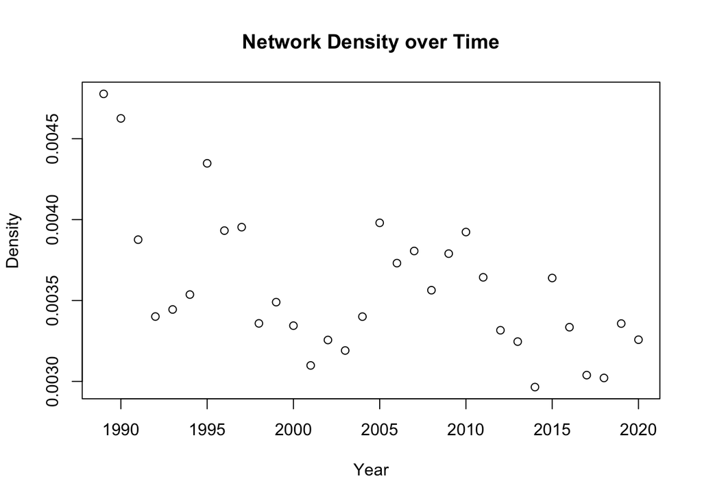

```r
plot(densities, main="Network Density over Time")
```

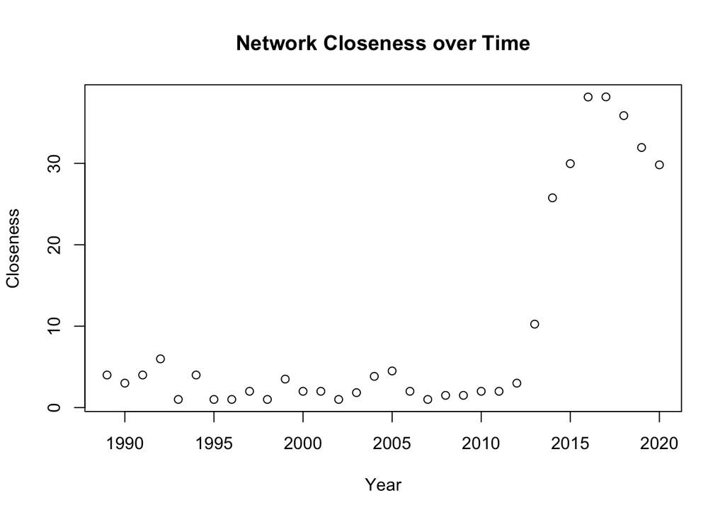

```r
plot(latoras, main="Network Closeness over Time") #sum of inversed distances to all other nodes instead of the inversed of the sum of distances to all other nodes
```

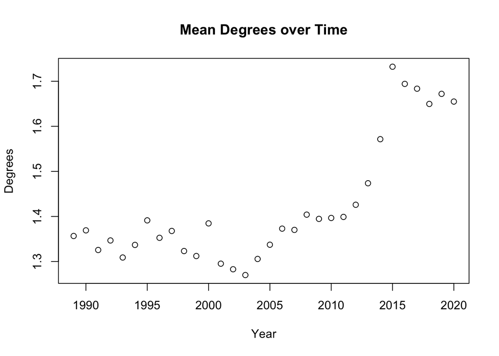

```r
plot(meandeg, main="Mean Degrees over Time")
```

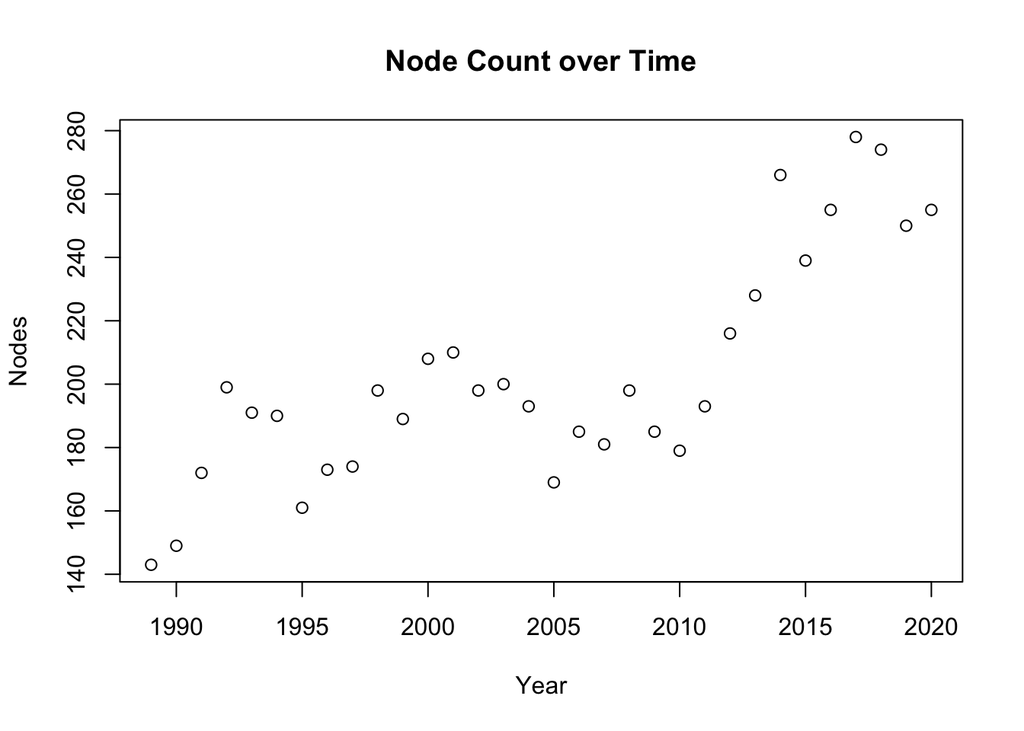

```r
plot(vertices_cnt, main="Node Count over Time")
```

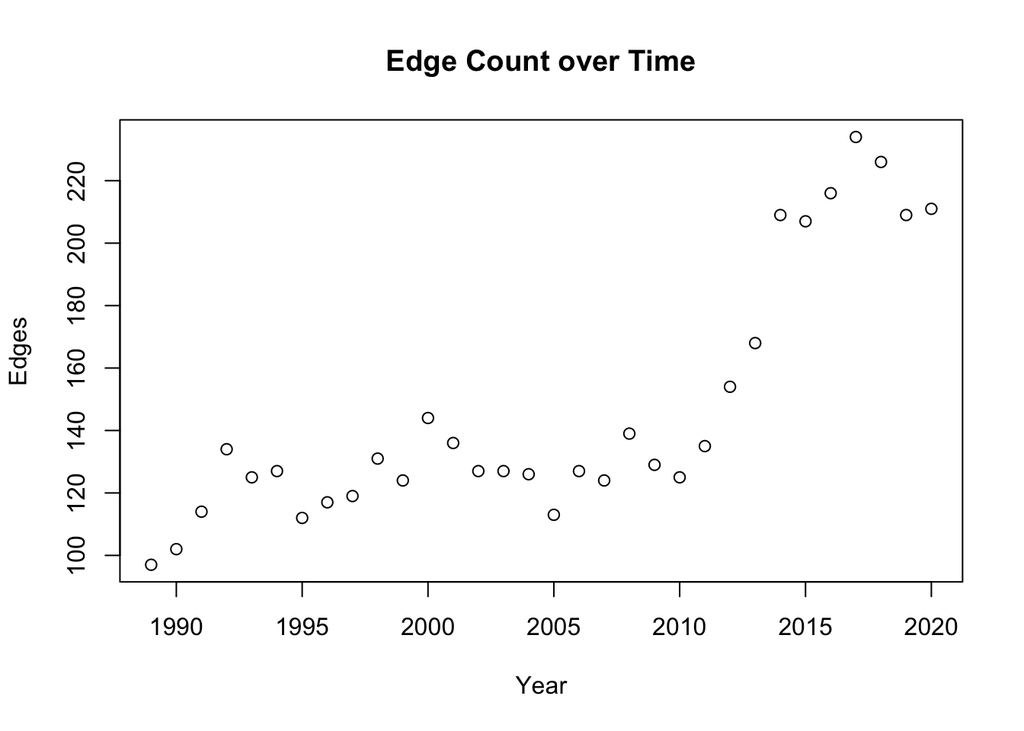

```r
plot(edges_cnt, main="Edge Count over Time")
```

```r
#Tidy and arrange

routes_tidy <- tbl_graph(nodes = nodes, edges = edges, directed = TRUE)
routes_igraph_tidy <- as_tbl_graph(routes_igraph)

routes_tidy %>%
  activate(edges) %>%
  arrange(desc(total))
```

```
## # A tbl_graph: 255 nodes and 211 edges
## #
## # A directed acyclic simple graph with 56 components
## #
## # Edge Data: 211 x 3 (active)
##    from    to total
##   <int> <int> <dbl>
## 1     1   127 20102
## 2     2   128  7633
## 3     3   129  4455
## 4     3   130  4362
## 5     4   131  3521
## 6     5    27  2330
## # … with 205 more rows
## #
## # Node Data: 255 x 1
##   sides
##   <chr>
## 1 Government of Afghanistan
## 2 Government of Azerbaijan
## 3 Jalisco Cartel New Generation
## # … with 252 more rows
```

```r
routes_tidy
```

```
## # A tbl_graph: 255 nodes and 211 edges
## #
## # A directed acyclic simple graph with 56 components
## #
## # Node Data: 255 x 1 (active)
##   sides
##   <chr>
## 1 Government of Afghanistan
## 2 Government of Azerbaijan
## 3 Jalisco Cartel New Generation
## 4 Government of Syria
## 5 Government of Yemen (North Yemen)
## 6 Comando Vermelho
## # … with 249 more rows
## #
## # Edge Data: 211 x 3
##    from    to total
##   <int> <int> <dbl>
## 1     1   127 20102
## 2     2   128  7633
## 3     3   129  4455
## # … with 208 more rows
```

```r
routes_tidy %>%
  activate(nodes) %>%
  mutate(degree = centrality_degree(mode = 'total'))
```

```
## # A tbl_graph: 255 nodes and 211 edges
## #
## # A directed acyclic simple graph with 56 components
## #
## # Node Data: 255 x 2 (active)
##   sides                             degree
##   <chr>                              <dbl>
## 1 Government of Afghanistan              3
## 2 Government of Azerbaijan               1
## 3 Jalisco Cartel New Generation          7
## 4 Government of Syria                    3
## 5 Government of Yemen (North Yemen)      3
## 6 Comando Vermelho                       2
## # … with 249 more rows
## #
## # Edge Data: 211 x 3
##    from    to total
##   <int> <int> <dbl>
## 1     1   127 20102
## 2     2   128  7633
## 3     3   129  4455
## # … with 208 more rows
```

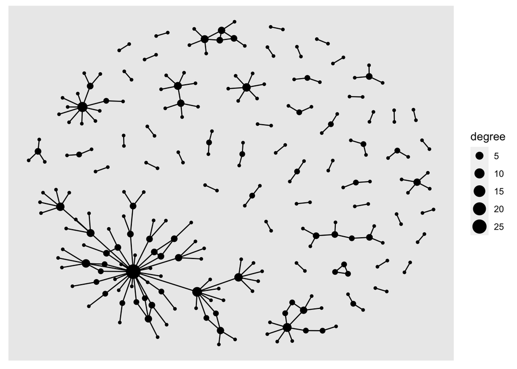

```r
routes_tidy %>%
  activate(nodes)%>%
  mutate(degree = centrality_degree(mode = 'total'))  %>%
  ggraph('nicely') +
  geom_node_point(aes(size = degree)) +
  geom_edge_link()
```

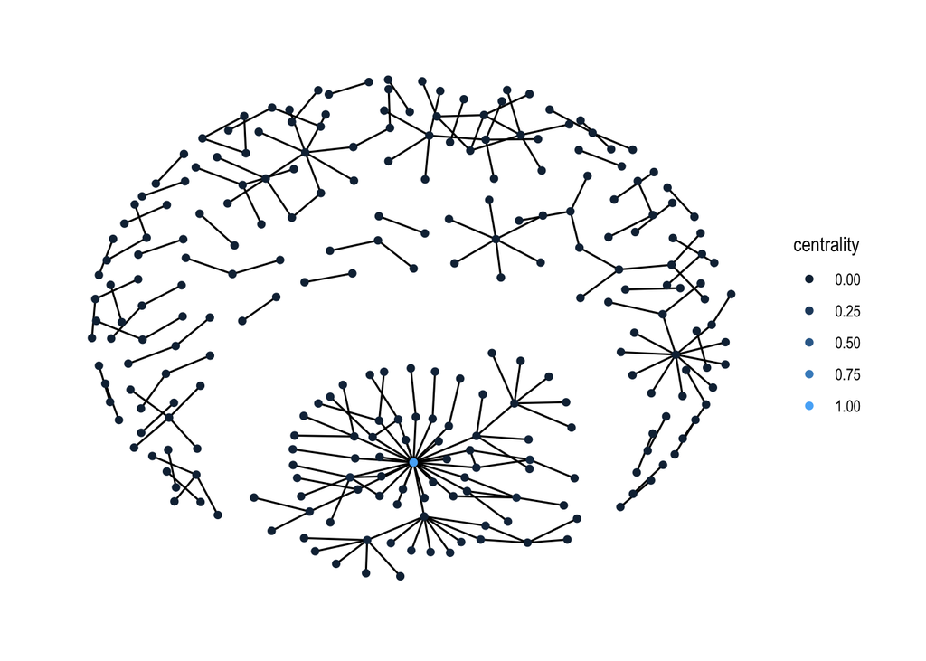

```r
routes_tidy %>%
    mutate(centrality = centrality_authority()) %>%
    ggraph(layout = 'kk') +
    geom_edge_link() +
    geom_node_point(aes(colour = centrality)) +
    scale_color_continuous(guide = 'legend') +
    theme_graph()
```

As we can see, the edges are not weighted

```r
is.weighted(routes_igraph)
```

```
## [1] FALSE
```

So let’s weight by the total deaths in for conflict

```r
#Tidy and arrange
#tidygraph
routes_tidy <- tbl_graph(nodes = nodes, edges = edges, directed = TRUE)
routes_igraph_tidy <- as_tbl_graph(routes_igraph)

routes_tidy %>%
  activate(edges) %>%
  arrange(desc(total))
```

```
## # A tbl_graph: 255 nodes and 211 edges
## #
## # A directed acyclic simple graph with 56 components
## #
## # Edge Data: 211 x 3 (active)
##    from    to total
##   <int> <int> <dbl>
## 1     1   127 20102
## 2     2   128  7633
## 3     3   129  4455
## 4     3   130  4362
## 5     4   131  3521
## 6     5    27  2330
## # … with 205 more rows
## #
## # Node Data: 255 x 1
##   sides
##   <chr>
## 1 Government of Afghanistan
## 2 Government of Azerbaijan
## 3 Jalisco Cartel New Generation
## # … with 252 more rows
```

```r
routes_tidy %>%
  activate(nodes) %>%
  mutate(degree = centrality_degree(mode = 'total'))
```

```
## # A tbl_graph: 255 nodes and 211 edges
## #
## # A directed acyclic simple graph with 56 components
## #
## # Node Data: 255 x 2 (active)
##   sides                             degree
##   <chr>                              <dbl>
## 1 Government of Afghanistan              3
## 2 Government of Azerbaijan               1
## 3 Jalisco Cartel New Generation          7
## 4 Government of Syria                    3
## 5 Government of Yemen (North Yemen)      3
## 6 Comando Vermelho                       2
## # … with 249 more rows
## #
## # Edge Data: 211 x 3
##    from    to total
##   <int> <int> <dbl>
## 1     1   127 20102
## 2     2   128  7633
## 3     3   129  4455
## # … with 208 more rows
```

```r
head(E(routes_tidy)$total)
```

```
## [1] 20102  7633  4455  4362  3521  2330
```

```r
routes_tidy <- set_edge_attr(routes_tidy, "weight", value= E(routes_tidy)$total)
is_weighted(routes_tidy)
```

```
## [1] TRUE
```

```r
E(routes_tidy)[E(routes_tidy)$weight>0]
```

```
## + 211/211 edges from 87696e2:
##  [1]  1->127  2->128  3->129  3->130  4->131  5-> 27  3->132  6->133  7-> 92
## [10]  3->134  8-> 20  9->135  3->136  4-> 20 10->129 11-> 20 12-> 20 13->100
## [19] 14-> 20  3->137 15-> 20 16->103 17->138 18->113  8->117 19->139 20->103
## [28] 21->140 22->103 23-> 20  1-> 20 24-> 30 25->141 26->142 27->143 28->144
## [37] 29->145 30->146 31->147 32->148  6->149 25-> 31 22-> 20 33->150 25->151
## [46] 34-> 20 35->144 20->138 36->137 37->152 31->153 38->154 39->155 40->103
## [55] 41-> 39 32->156 42->157 43-> 92 44->158  3->159 14-> 49 45->160 46-> 42
## [64] 47->161 48->162 32-> 20 14-> 51 49-> 42 37->163 50->164 51->165 52->142
## [73] 14->166 53->167 16-> 20 51->168 54->169 55->142 56-> 95 57->170 53->171
## [82]  1->172 58->103 34->173 59->174 59->175 14->176 60->177 61->178 62->179
## + ... omitted several edges
```

```r
nodes[c(652,130,6,14,240,14,653,654,37,285,655,656,657),]
```

```
##  [1] NA                               "Santa Rosa de Lima Cartel"
##  [3] "Comando Vermelho"               "Government of DR Congo (Zaire)"
##  [5] "Egbura Mozum"                   "Government of DR Congo (Zaire)"
##  [7] NA                               NA
##  [9] "Government of Ukraine"          NA
## [11] NA                               NA
## [13] NA
```

```r
nodes[1:10,]
```

```
##  [1] "Government of Afghanistan"         "Government of Azerbaijan"
##  [3] "Jalisco Cartel New Generation"     "Government of Syria"
##  [5] "Government of Yemen (North Yemen)" "Comando Vermelho"
##  [7] "Government of Somalia"             "Government of Nigeria"
##  [9] "Government of Ethiopia"            "Juarez Cartel"
```

```r
head(closeness.latora(routes_tidy, vids = V(routes_tidy))) #Latora centrality for disconnected graphs
```

```
## [1] 0.1518159541 0.0001310101 0.0382130330 0.3915847692 0.8908332205
## [6] 0.0065505620
```

Using this we can see what the distribution of closeness looks like

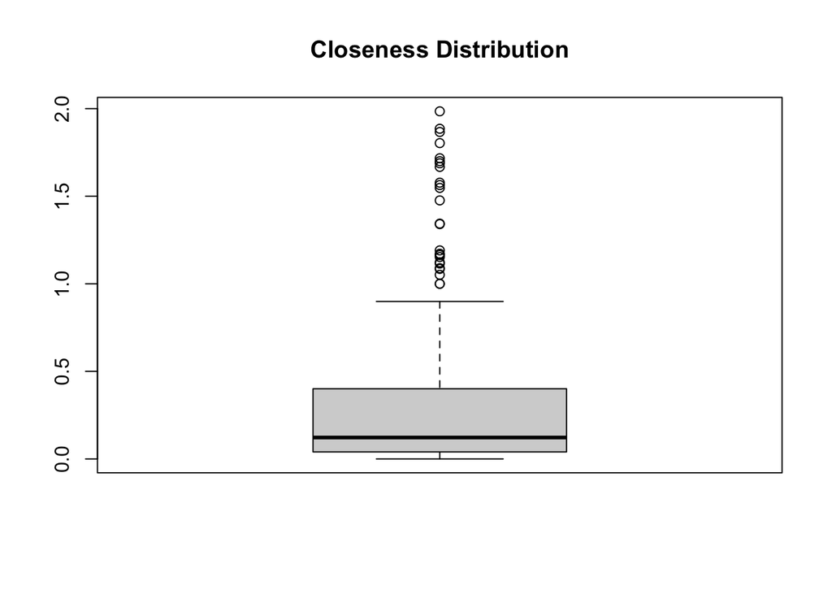

```r
boxplot(closeness.latora(routes_tidy, vids = V(routes_tidy)), main="Closeness Distribution")
```

```r
#library(ggraph)
#ggraph(routes_tidy, layout = "graphopt") +   geom_node_point() +  geom_edge_link(aes(width = "weight"), alpha = 0.8) +   scale_edge_width(range = c(0.1, 3)) +  geom_node_text(aes(label = sides), repel = TRUE) +  labs(edge_width = "weight") +  theme_graph()
```

Interactive Plot with visNetwork and D3forcenetworklibrary

Jesse Sadler. (2017, October 25). Introduction to Network Analysis with R. Retrieved from https://www.jessesadler.com/post/network-analysis-with-r/

Bradley, B. (2021, May 25). From igraph to visNetwork. Retrieved from https://towardsdatascience.com/from-igraph-to-visnetwork-7bc5a76fdeec

```r
visIgraph(routes_igraph)
```

[interactive chart not shown]

```r
visIgraph(routes_igraph) %>% visOptions(nodesIdSelection = TRUE,  highlightNearest = TRUE)
```

[interactive chart not shown]

```r
library(networkD3)
library(visNetwork)

#This finds the subclusters
sc <- cluster_walktrap(routes_igraph)
members <- membership(sc)

#Converting from igraph to a d3 network type
plt_d3 <- igraph_to_networkD3(routes_igraph, group = members)

#This creates the plot
pltint <- forceNetwork(Links = plt_d3$links, Nodes =plt_d3$nodes,
             Source = 'source', Target = 'target', NodeID = 'name',Group = 'group', fontSize = 30, opacity = 1, zoom = TRUE)

pltint
```

[interactive chart not shown]

```r
#This saves the plot as an html file
saveWidget(pltint, "network.html")
```

## Libraries Used

### Documentation and functionality

readr: https://www.rdocumentation.org/packages/readr/versions/1.3.1 dplyr: https://www.rdocumentation.org/packages/dplyr/versions/0.7.8 ggplot2: https://ggplot2.tidyverse.org/

Inferring and Analysing the Network network: https://cran.r-project.org/web/packages/network/index.html igraph: https://igraph.org/r/ centiserve: https://www.centiserver.org/rpackage/ tidygraph: https://www.rdocumentation.org/packages/tidygraph/versions/1.2.0

Visualising the Network networkD3: https://www.rdocumentation.org/packages/networkD3/versions/0.4 visNetwork: https://www.rdocumentation.org/packages/visNetwork/versions/2.1.0 htmlwidgets: https://www.htmlwidgets.org/ ggraph: https://cran.r-project.org/web/packages/ggraph/index.html

## Sources Used

### For the interactive plots:

Jesse Sadler. (2017, October 25). Introduction to Network Analysis with R. Retrieved from https://www.jessesadler.com/post/network-analysis-with-r/

Bradley, B. (2021, May 25). From igraph to visNetwork. Retrieved from https://towardsdatascience.com/from-igraph-to-visnetwork-7bc5a76fdeec